# Risk Factor Analysis

## Outcome Variable

**Outcome Variable:** s03rec24

## Predictor Variables

**Intervention Variable:** enstunt

**Adjustment Set:**

unadjusted

## Stratifying Variables

The analysis was stratified on these variable(s):

- studyid
- country

## Data Summary

| studyid | country | A | n | nA | nAY0 | nAY1 |
| --- | --- | --- | --- | --- | --- | --- |
| ki0047075b-MAL-ED | BANGLADESH | 0 | 239 | 207 | 206 | 1 |
| ki0047075b-MAL-ED | BANGLADESH | 1 | 239 | 32 | 25 | 7 |
| ki0047075b-MAL-ED | BRAZIL | 0 | 182 | 169 | 166 | 3 |
| ki0047075b-MAL-ED | BRAZIL | 1 | 182 | 13 | 1 | 12 |
| ki0047075b-MAL-ED | INDIA | 0 | 201 | 173 | 172 | 1 |
| ki0047075b-MAL-ED | INDIA | 1 | 201 | 28 | 19 | 9 |
| ki0047075b-MAL-ED | NEPAL | 0 | 172 | 155 | 154 | 1 |
| ki0047075b-MAL-ED | NEPAL | 1 | 172 | 17 | 11 | 6 |
| ki0047075b-MAL-ED | PERU | 0 | 269 | 244 | 233 | 11 |
| ki0047075b-MAL-ED | PERU | 1 | 269 | 25 | 19 | 6 |
| ki0047075b-MAL-ED | SOUTH AFRICA | 0 | 253 | 233 | 226 | 7 |
| ki0047075b-MAL-ED | SOUTH AFRICA | 1 | 253 | 20 | 10 | 10 |
| ki0047075b-MAL-ED | TANZANIA, UNITED REPUBLIC OF | 0 | 120 | 105 | 105 | 0 |
| ki0047075b-MAL-ED | TANZANIA, UNITED REPUBLIC OF | 1 | 120 | 15 | 15 | 0 |
| ki1000108-CMC-V-BCS-2002 | INDIA | 0 | 98 | 82 | 80 | 2 |
| ki1000108-CMC-V-BCS-2002 | INDIA | 1 | 98 | 16 | 13 | 3 |
| ki1000108-IRC | INDIA | 0 | 410 | 362 | 349 | 13 |
| ki1000108-IRC | INDIA | 1 | 410 | 48 | 33 | 15 |
| ki1000109-EE | PAKISTAN | 0 | 5 | 5 | 5 | 0 |
| ki1000109-EE | PAKISTAN | 1 | 5 | 0 | 0 | 0 |
| ki1000109-ResPak | PAKISTAN | 0 | 49 | 49 | 49 | 0 |
| ki1000109-ResPak | PAKISTAN | 1 | 49 | 0 | 0 | 0 |
| ki1066203-TanzaniaChild2 | TANZANIA, UNITED REPUBLIC OF | 0 | 19 | 18 | 18 | 0 |
| ki1066203-TanzaniaChild2 | TANZANIA, UNITED REPUBLIC OF | 1 | 19 | 1 | 1 | 0 |
| ki1101329-Keneba | GAMBIA | 0 | 2467 | 2235 | 2200 | 35 |
| ki1101329-Keneba | GAMBIA | 1 | 2467 | 232 | 187 | 45 |
| ki1113344-GMS-Nepal | NEPAL | 0 | 52 | 43 | 43 | 0 |
| ki1113344-GMS-Nepal | NEPAL | 1 | 52 | 9 | 8 | 1 |
| ki1114097-CMIN | BANGLADESH | 0 | 7 | 7 | 7 | 0 |
| ki1114097-CMIN | BANGLADESH | 1 | 7 | 0 | 0 | 0 |
| ki1114097-CMIN | PERU | 0 | 105 | 103 | 103 | 0 |
| ki1114097-CMIN | PERU | 1 | 105 | 2 | 2 | 0 |
| ki1114097-CONTENT | PERU | 0 | 54 | 48 | 47 | 1 |
| ki1114097-CONTENT | PERU | 1 | 54 | 6 | 3 | 3 |

The following strata were considered:

- studyid: ki0047075b-MAL-ED, country: BANGLADESH
- studyid: ki0047075b-MAL-ED, country: BRAZIL
- studyid: ki0047075b-MAL-ED, country: INDIA
- studyid: ki0047075b-MAL-ED, country: NEPAL
- studyid: ki0047075b-MAL-ED, country: PERU
- studyid: ki0047075b-MAL-ED, country: SOUTH AFRICA
- studyid: ki0047075b-MAL-ED, country: TANZANIA, UNITED REPUBLIC OF
- studyid: ki1000108-CMC-V-BCS-2002, country: INDIA
- studyid: ki1000108-IRC, country: INDIA
- studyid: ki1000109-EE, country: PAKISTAN
- studyid: ki1000109-ResPak, country: PAKISTAN
- studyid: ki1066203-TanzaniaChild2, country: TANZANIA, UNITED REPUBLIC OF
- studyid: ki1101329-Keneba, country: GAMBIA
- studyid: ki1113344-GMS-Nepal, country: NEPAL
- studyid: ki1114097-CMIN, country: BANGLADESH
- studyid: ki1114097-CMIN, country: PERU
- studyid: ki1114097-CONTENT, country: PERU

### Dropped Strata

Some strata were dropped due to rare outcomes:

- studyid: ki0047075b-MAL-ED, country: BANGLADESH
- studyid: ki0047075b-MAL-ED, country: BRAZIL
- studyid: ki0047075b-MAL-ED, country: INDIA
- studyid: ki0047075b-MAL-ED, country: NEPAL
- studyid: ki0047075b-MAL-ED, country: TANZANIA, UNITED REPUBLIC OF
- studyid: ki1000108-CMC-V-BCS-2002, country: INDIA
- studyid: ki1000109-EE, country: PAKISTAN
- studyid: ki1000109-ResPak, country: PAKISTAN
- studyid: ki1066203-TanzaniaChild2, country: TANZANIA, UNITED REPUBLIC OF
- studyid: ki1113344-GMS-Nepal, country: NEPAL
- studyid: ki1114097-CMIN, country: BANGLADESH
- studyid: ki1114097-CMIN, country: PERU
- studyid: ki1114097-CONTENT, country: PERU

## Methods Detail

We’re interested in the causal parameters $E[Y_a]$ for all values of $a \in \mathcal{A}$. These parameters represent the mean outcome if, possibly contrary to fact, we intervened to set all units to have $A=a$. Under the randomization and positivity assumptions, these are identified by the statistical parameters $\psi_a=E_W[E_{Y|A,W}(Y|A=a,W)]$. In addition, we’re interested in the mean of $Y$, $E[Y]$ under no intervention (the observed mean). We will estimate these parameters by using SuperLearner to fit the relevant likelihood factors – $E_{Y|A,W}(Y|A=a,W)$ and $p(A=a|W)$, and then updating our likelihood fit using a joint TMLE.

For unadjusted analyses ($W=\{\}$), initial likelihoods were estimated using Lrnr_glm to estimate the simple $E(Y|A)$ and Lrnr_mean to estimate $p(A)$. For adjusted analyses, a small library containing Lrnr_glmnet, Lrnr_xgboost, and Lrnr_mean was used.

Having estimated these parameters, we will then use the delta method to estimate relative risks and attributable risks relative to a prespecified baseline level of $A$.

# Results Detail

## Results Plots

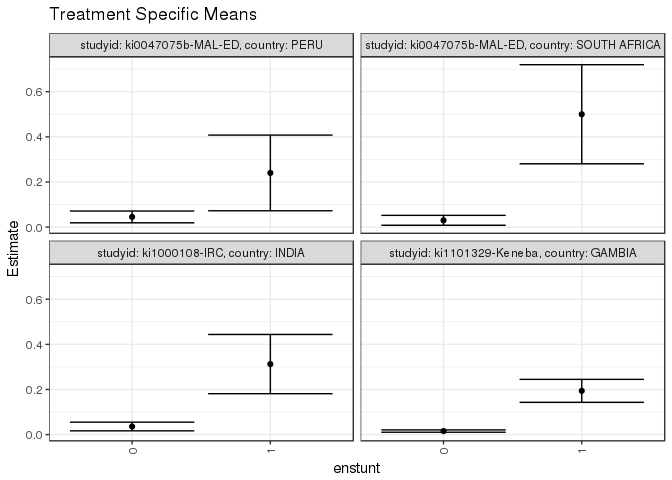

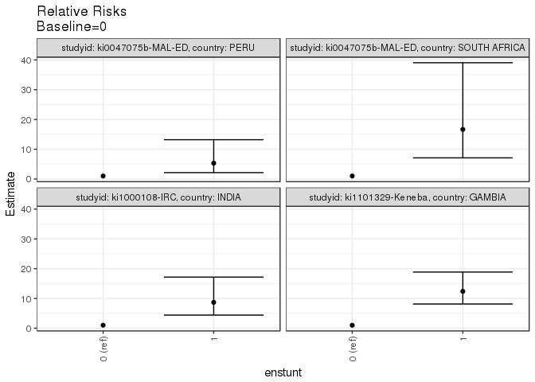

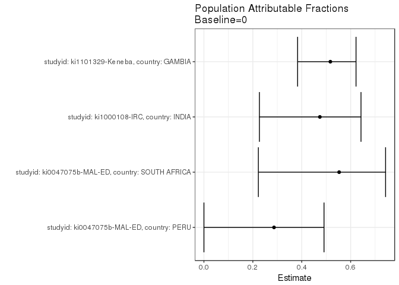

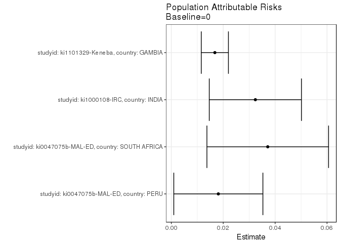

## Results Table

### Parameter: TSM

| studyid | country | intervention_level | baseline_level | estimate | ci_lower | ci_upper |
| --- | --- | --- | --- | --- | --- | --- |
| ki0047075b-MAL-ED | PERU | 0 | NA | 0.0450820 | 0.0189996 | 0.0711643 |
| ki0047075b-MAL-ED | PERU | 1 | NA | 0.2400000 | 0.0722744 | 0.4077256 |
| ki0047075b-MAL-ED | SOUTH AFRICA | 0 | NA | 0.0300429 | 0.0080806 | 0.0520052 |
| ki0047075b-MAL-ED | SOUTH AFRICA | 1 | NA | 0.5000000 | 0.2804350 | 0.7195650 |
| ki1000108-IRC | INDIA | 0 | NA | 0.0359116 | 0.0167205 | 0.0551027 |
| ki1000108-IRC | INDIA | 1 | NA | 0.3125000 | 0.1812138 | 0.4437862 |
| ki1101329-Keneba | GAMBIA | 0 | NA | 0.0156600 | 0.0105116 | 0.0208083 |
| ki1101329-Keneba | GAMBIA | 1 | NA | 0.1939655 | 0.1430757 | 0.2448554 |

### Parameter: E(Y)

| studyid | country | intervention_level | baseline_level | estimate | ci_lower | ci_upper |
| --- | --- | --- | --- | --- | --- | --- |
| ki0047075b-MAL-ED | PERU | NA | NA | 0.0631970 | 0.0340662 | 0.0923279 |
| ki0047075b-MAL-ED | SOUTH AFRICA | NA | NA | 0.0671937 | 0.0362831 | 0.0981043 |
| ki1000108-IRC | INDIA | NA | NA | 0.0682927 | 0.0438464 | 0.0927390 |
| ki1101329-Keneba | GAMBIA | NA | NA | 0.0324281 | 0.0254368 | 0.0394193 |

### Parameter: RR

| studyid | country | intervention_level | baseline_level | estimate | ci_lower | ci_upper |
| --- | --- | --- | --- | --- | --- | --- |
| ki0047075b-MAL-ED | PERU | 0 | 0 | 1.000000 | 1.000000 | 1.00000 |
| ki0047075b-MAL-ED | PERU | 1 | 0 | 5.323636 | 2.148768 | 13.18947 |
| ki0047075b-MAL-ED | SOUTH AFRICA | 0 | 0 | 1.000000 | 1.000000 | 1.00000 |
| ki0047075b-MAL-ED | SOUTH AFRICA | 1 | 0 | 16.642857 | 7.093630 | 39.04696 |
| ki1000108-IRC | INDIA | 0 | 0 | 1.000000 | 1.000000 | 1.00000 |
| ki1000108-IRC | INDIA | 1 | 0 | 8.701923 | 4.409583 | 17.17248 |
| ki1101329-Keneba | GAMBIA | 0 | 0 | 1.000000 | 1.000000 | 1.00000 |
| ki1101329-Keneba | GAMBIA | 1 | 0 | 12.386084 | 8.133237 | 18.86273 |

### Parameter: PAR

| studyid | country | intervention_level | baseline_level | estimate | ci_lower | ci_upper |
| --- | --- | --- | --- | --- | --- | --- |
| ki0047075b-MAL-ED | PERU | 0 | NA | 0.0181151 | 0.0009463 | 0.0352838 |
| ki0047075b-MAL-ED | SOUTH AFRICA | 0 | NA | 0.0371508 | 0.0137118 | 0.0605897 |
| ki1000108-IRC | INDIA | 0 | NA | 0.0323811 | 0.0146171 | 0.0501451 |
| ki1101329-Keneba | GAMBIA | 0 | NA | 0.0167681 | 0.0115377 | 0.0219985 |

### Parameter: PAF

| studyid | country | intervention_level | baseline_level | estimate | ci_lower | ci_upper |
| --- | --- | --- | --- | --- | --- | --- |
| ki0047075b-MAL-ED | PERU | 0 | NA | 0.2866442 | 0.0000928 | 0.4910762 |
| ki0047075b-MAL-ED | SOUTH AFRICA | 0 | NA | 0.5528907 | 0.2226346 | 0.7428407 |
| ki1000108-IRC | INDIA | 0 | NA | 0.4741515 | 0.2268928 | 0.6423308 |
| ki1101329-Keneba | GAMBIA | 0 | NA | 0.5170861 | 0.3830629 | 0.6219942 |